# Divvy Study Analysis Markdown

2023-07-24

G. Gallagher

- Initial Areas of Investigation
- Load in Data
- 1st Pass
  - How does the number of members/casuals change over the year/week/day?
    - Yearly
    - Weekly
    - Filter for days with exceptionally high usage (>15000)
    - Public Holiday Comparison
    - Daily
    - Summer - Winter Split
    - Overall takeaways:
    - Conclusions Drawn:
    - Caveats:
  - What are the differences in trip length for the two groups?
  - What is the average speed of the two groups?
  - What are the differences in docking stations used by the two groups?
  - How does the popularity of stations compare against the number of docks at the station?
  - Are there any connections between particular high/low member/casual usage and location?
  - The regularity of trips(to/from work etc…)?
  - What are the preferences for electric bikes vs classic bikes between the two groups
  - Looking at bike type preference across the year and across the two user groups
  - What are the differences in the group size/composition during trips of the two groups?
  - Are there any dips in casual usage that align with rise in member usage?
- 2nd Pass
  - Formulating the strongest and most promising data and conclusions into a report:
  - Graphing Daily Journey Totals against Time
  - Graphing Variance in Daily Journey Totals according to Day of The Week
  - Percentage of Casual trips that fall under this “Peak Season” umbrella

# Initial Areas of Investigation

- How does the number of members/casuals change over the year/week/day?
- How does the proportion of members to casuals change over the year/week/day?
- What are the differences in trip length for the two groups?
- What is the average speed of the two groups?
- What are the differences in docking stations used by the two groups?
- How does the popularity of stations compare against the number of docks at the station? (Are some stations running out of available bikes)
- Are there any connections between particular high/low member/casual usage and location?
- The regularity of trips(to/from work etc…)?
- What are the differences in the group size during trips of the two groups?
- Are there any dips in casual usage that align with a rise in member usage?

# Load in Data

```r
trips <- read.csv("Cleaned Datasets//Cleaned_Trips_Dataset.csv")
trips_wloc <- read.csv("Cleaned Datasets//Cleaned_Trips_W_Location_Dataset.csv")
stns_mst <- read.csv("Cleaned Datasets//Stations_Dataset.csv")
```

# 1st Pass

## How does the number of members/casuals change over the year/week/day?

### Yearly

```r
mcWRTtime <- tibble("date" = as.Date(trips$s_at), "m_c" = trips$m_c)
mcWRTtime <- table(mcWRTtime)
mcWRTtime <- as.data.frame(mcWRTtime)
mcWRTtime$date <- as.Date(as.character(mcWRTtime$date), format="%Y-%m-%d")
mcWRTtime$m_c <- factor(mcWRTtime$m_c, levels = c("member", "casual"))

g_mcWRTtime <- mcWRTtime %>%
  ggplot(aes(date, Freq, color = m_c, group = m_c)) +
  geom_point(alpha = 0.3) +
  geom_line(alpha = 0.3) +
  geom_smooth() +
  labs(x = "2022/23",
       y = "Number or Rides Taken",
       title = "Usage Statistics of Customers",
       color = "Customer Type") +
  scale_x_date(breaks = "1 month", date_labels = "%B") +
  scale_colour_manual(values = c("#ffa600", "#003f5c"),
                      labels = c("Member", "Casual")) +
  theme_bw()

g_mcWRTtime
```

[output not shown]

Generally member numbers higher, but with a lot of variance, will take a closer look at how they align to days of the week.

### Weekly

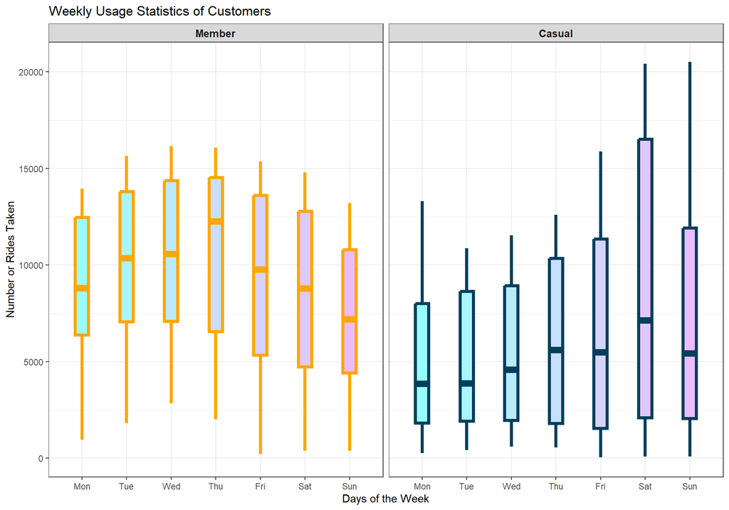

```r
wd <- wday(mcWRTtime$date, week_start = 1)
mcWRTwd <- cbind(mcWRTtime, wd)
remove(wd)

g_mcWRTwd <- mcWRTwd %>%
  ggplot(aes(wd, Freq, group = wd, fill = wd, color = m_c)) +
  geom_boxplot(show.legend = F,
               outlier.shape = NA,
               width = .3,
               size = 1.5) +
  labs(x = "Days of the Week",
       y = "Number or Rides Taken",
       title = "Weekly Usage Statistics of Customers",
       color = "Customer Type") +
  scale_x_discrete(limits = 1:7, labels = c("1" = "Mon", "2" = "Tue",
                                          "3" = "Wed", "4" = "Thu",
                                          "5" = "Fri", "6" = "Sat",
                                          "7" =  "Sun")) +
  scale_colour_manual(values = c("#ffa600", "#003f5c"),
                      labels = c("Member", "Casual")) +
  scale_fill_gradient(low = "#97FFFD", high = "#ECBBFF") +
  facet_wrap(~m_c,
             labeller = labeller(m_c = c("member" = "Member",
                                         "casual" = "Casual"))) +
  theme_bw() +
  theme(strip.text.x = element_text(size = 10, face = "bold"))
g_mcWRTwd
```

Means for Causal users are consistently lower which conforms with the previous viz. However, while member usage is consistently higher throughout the week but less so at the weekend. Could suggest a weekend membershipwould be of value or a four day Fri - Mon. The high variance of the Casual weekend use suggests maybe a cherry pickedseason could be beneficial. Deserves a closer look

### Filter for days with exceptionally high usage (>15000)

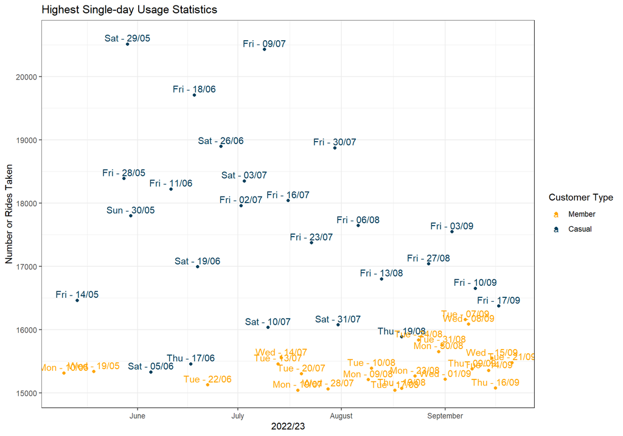

```r
high_usage <- filter(mcWRTwd, Freq > 15000)
high_usage <- arrange(high_usage, desc(Freq))

g_highusage <- high_usage %>%
  ggplot(aes(date, Freq, color = m_c, group = m_c)) +
  geom_point() +
  geom_text(aes(label = paste(wday(wd, label = T), "-", format(date, "%d/%m"))),
            nudge_y = 100) +
  labs(x = "2022/23",
       y = "Number or Rides Taken",
       title = "Highest Single-day Usage Statistics",
       color = "Customer Type") +
  scale_x_date(breaks = "1 month", date_labels = "%B") +
  scale_colour_manual(values = c("#ffa600", "#003f5c"),
                      labels = c("Member", "Casual")) +
  theme_bw()

g_highusage
```

Top 20 Highest single day usage by any one group are all from casual users. We can also gather that all the top Casual usage days are during summer, and from Thurs - Sun

I want to look again at the overview, there were other peaks that fell outside of the summer months, which I want to see if I can explain. I’ll try to align the data to that of public holidays in Chicago.

### Public Holiday Comparison

[figure not shown]

```r
public_holidays <- tibble("Day" = c("Mother's Day", "Memorial Day",
                                    "Father's Day", "Independence Day",
                                    "Labor Day","Columbus Day","Election Day",
                                    "Veterans Day", "Thanksgiving",
                                    "Day after Thanksgiving", "Christmas Day",
                                    "Christmas Day (in lieu)", "New Year's Day",
                                    "Dr. Martin Luther King Jr.'s Birthday",
                                    "Lincoln's Birthday",
                                    "Washington's Birthday", "Pulaski Day"),
            "Date" = as.Date(c("5/8/2022", "5/30/2022","6/19/2022","7/4/2022",
              "9/5/2022","10/10/2022","11/8/2022","11/11/2022",
              "11/24/2022", "11/25/2022","12/25/2022","12/26/2022",
              "1/2/2023","1/16/2023", "2/13/2023","2/20/2023","3/6/2023"),
              "%m/%d/%Y"))

g_usageWRTpubhol <- mcWRTtime %>%
  ggplot(aes(date, Freq, color = m_c, group = m_c)) +
  geom_bar(data = public_holidays, aes(x = Date, y = 22000:22016, color = NA,
                                       group = NA, fill = "pink"),
           stat='identity', alpha = 0.3) +
  geom_point(alpha = 0.3) +
  geom_line(alpha = 0.3) +
  geom_smooth() +
  labs(x = "2022/23",
       y = "Number or Rides Taken",
       title = "Usage Statistics of Customers, With Highlighted Public Holidays",
       color = "Customer Type") +
  scale_x_date(breaks = "1 month", date_labels = "%B") +
  scale_colour_manual(values = c("#ffa600", "#003f5c", "red"),
                      labels = c("Member", "Casual", "Public Holidays")) +
  theme_bw()

g_usageWRTpubhol
```

No concrete correlation here, and does not explain the peaks around early November ’22 or mid April ’23

Finally I think it’s could be worth looking at how usage changes over the course of a day?

### Daily

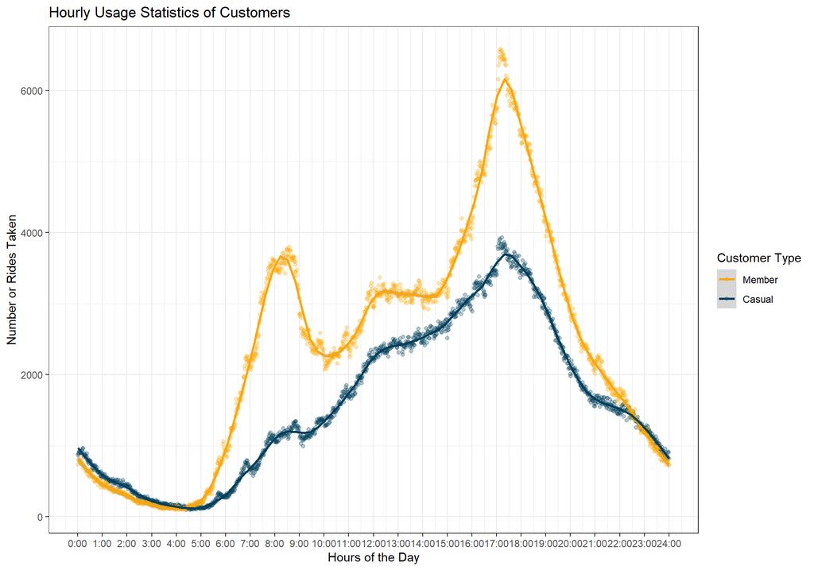

```r
usageWRTtimeofday <- tibble("time_of_day" = hms::as_hms(ymd_hms(trips$s_at)),
                            "m_c" = trips$m_c)

usageWRTtimeofday$time_of_day <- usageWRTtimeofday$time_of_day %>%
  as.character(.) %>%
  strtrim(., width = 5) %>%
  paste0(., ":00") %>%
  hms::as_hms(.)

usageWRTtimeofday <- table(usageWRTtimeofday)
usageWRTtimeofday <- as.data.frame(usageWRTtimeofday)
usageWRTtimeofday$m_c <- factor(usageWRTtimeofday$m_c,
                                levels = c("member", "casual"))

g_mcWRTtod <- usageWRTtimeofday %>%
  ggplot(aes(time_of_day, Freq, color = m_c, group = m_c)) +
  geom_point(alpha = 0.3) +
  geom_smooth(method = "loess", span = 0.1) +
    labs(x = "Hours of the Day",
       y = "Number or Rides Taken",
       title = "Hourly Usage Statistics of Customers",
       color = "Customer Type") +
  scale_x_time(breaks = minutes(0:24),
               labels = c(paste0(0:24, ":00"))) +
  scale_colour_manual(values = c("#ffa600", "#003f5c"),
                      labels = c("Member", "Casual")) +
  theme_bw()

g_mcWRTtod
```

Fairly unsurprising pattern, peaks likely correlating with journeys to and from work, and with lunchtime. Casual usage matches up fairly well with trend line of Member usage, albeit with generally less usage. There is one notable insight to be gleamed; that the morning usage is significantly less than the afternoon usage. Perhaps an off-peak membership would balance this out.

Bearing in mind the significant change in casual usage during the summer and at the weekends, I think it due diligence to break this down further dependent on those factors.

### Summer - Winter Split

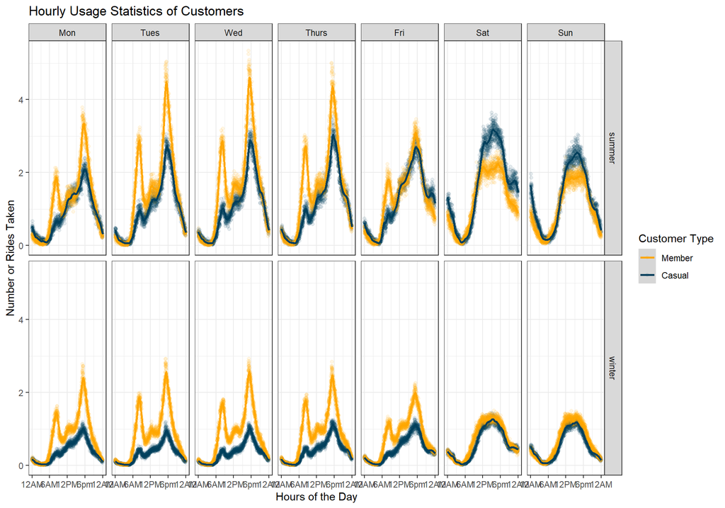

```r
usageWRTtod_sw <- tibble("time_of_day" = hms::as_hms(ymd_hms(trips$s_at)),
                            "m_c" = trips$m_c,
                            "wd" = wday(trips$s_at, week_start = 1),
                            "summer_winter" =
                              ifelse(as.Date(trips$s_at,
                                             format = "%Y-%m-%dT%H:%M:%SZ")
                                     < as.Date("21/06/2022",
                                               format = "%d/%m/%Y") |
                                       as.Date(trips$s_at,
                                               format = "%Y-%m-%dT%H:%M:%SZ")
                                     > as.Date("22/09/2022",
                                               format = "%d/%m/%Y"),
                                     "winter", "summer"))

usageWRTtod_sw$time_of_day <- usageWRTtod_sw$time_of_day %>%
  as.character(.) %>%
  strtrim(., width = 5) %>%
  paste0(., ":00") %>%
  hms::as_hms(.)

usageWRTtod_sw <- table(usageWRTtod_sw)
usageWRTtod_sw <- as.data.frame(usageWRTtod_sw)
usageWRTtod_sw$m_c <- factor(usageWRTtod_sw$m_c,
                                levels = c("member", "casual"))

usageWRTtod_sw <- mutate(usageWRTtod_sw,
                         mean_usage = ifelse(summer_winter == "summer",
                                             Freq/93, Freq/272))

g_mcWRTtod_sw <- usageWRTtod_sw %>%
  ggplot(aes(time_of_day, mean_usage)) +
  geom_point(alpha = 0.1, aes(color = m_c, group = m_c)) +
  geom_smooth(method = "loess", span = 0.1, aes(color = m_c, group = m_c)) +
  labs(x = "Hours of the Day",
       y = "Number or Rides Taken",
       title = "Hourly Usage Statistics of Customers",
       color = "Customer Type") +
  scale_x_time(breaks = minutes(seq(0,24,6)),
               labels=c("12AM","6AM","12PM","6pm","12AM")) +
  scale_colour_manual(values = c("#ffa600", "#003f5c"),
                      labels = c("Member", "Casual")) +
  facet_grid(summer_winter ~ wd, labeller = labeller(wd = c("1" = "Mon", "2" = "Tues",
                                            "3" = "Wed", "4" = "Thurs",
                                            "5" = "Fri", "6" = "Sat",
                                            "7" = "Sun"))) +
  theme_bw()

g_mcWRTtod_sw
```

Reaffirms previous conclusions, and adds that there is significant usage around midnight Fri/Sat and Sat/Sun during the summer.

### Overall takeaways:

- Member usage consistently higher than Casual usage throughout the year but less so during the summer.
- Member usage consistently higher than Casual usage throughout the week but less so during the weekend.
- Busiest days however, actually arise from Casual usage.
- Both user groups use the service more in the summer and less in the winter.
- High variance of day to day usage statistics for casual users during the summer.
- Low variance of day to day usage statistics for casual users during the winter.
- Members have a fairly consistent fluctuation in their day to day usage.
- Members use the service more during the the week, whereas casuals use the service more over the weekend.
- In fact Casual usage overtakes member usage for weekends during the summer.
- Usage has three peaks throughout the day, ~8:30 am, ~12:15pm, ~5:10pm.
- However on weekends there are no such peaks, but instead generally high traffic between ~12pm to ~6pm.
- Lowest traffic times fall between ~11pm to ~6am, with midday dips around 10am and again from ~8:30pm to ~11pm.

### Conclusions Drawn:

- A seasonal summer membership would likely meet the needs of a large proportion of casual users
- A weekends only membership would likely meet the needs of a large proportion of casual users
- Advertising and promotional offers will likely have the greatest effect during the summer, and even more specifically on summer weekends.
- The service is far less enticing for Casual users during the winter, however, since there is still sizable usage among members, it might be worth investigating how to improve the service for during winter. In general surveys would be a good method of investigating this further and this goes outside the scope of this analysis, but I will examine whether electric or classic bikes hold any useful information later.
- An off-peak membership with additional incentive for use would likely help smooth out the overall usage of the service as currently there are noticeable dips in usage, but this falls outside of the scope of this analysis as I am focusing on converting current casual users to members.

### Caveats:

- The service is finite, and I do not have access to information on what the total number of available bikes there are at any given time. Ergo, while for the scope of this analysis I am assuming that the usage statistics of one group has no effect on the usage statistics of the other; in actuality they very likely do affect each other to some degree.

## What are the differences in trip length for the two groups?

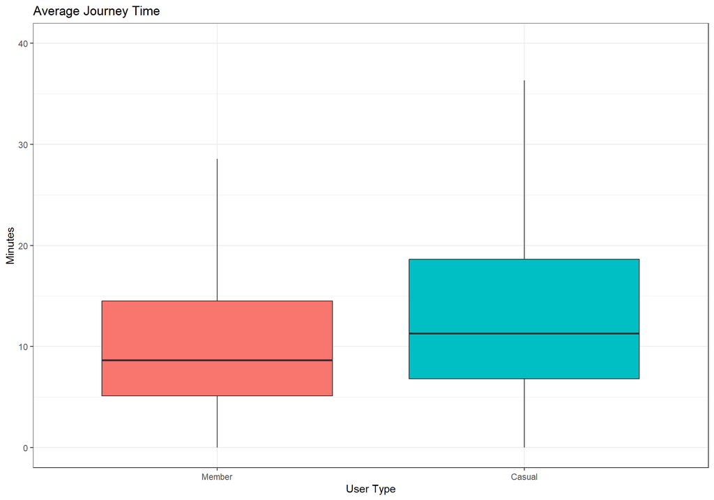

```r
mcWRTtl <- tibble("date" = as.Date(trips$s_at),
                  "time" = hms::as_hms(ymd_hms(trips$s_at)),
                  "m_c" = trips$m_c,
                  "length" = trips$length_time_mins)

mcWRTtl$time <- mcWRTtl$time %>%
  as.character(.) %>%
  strtrim(., width = 5) %>%
  paste0(., ":00") %>%
  hms::as_hms(.)

mcWRTtl$m_c <- factor(mcWRTtl$m_c, levels = c("member", "casual"))

mcWRTtl$length <- as.period(mcWRTtl$length)
mcWRTtl$length <- period_to_seconds(mcWRTtl$length)
mcWRTtl$length <- mcWRTtl$length / 60

g_mcWRTtl <- mcWRTtl %>%
  ggplot(aes(m_c, length, fill = m_c)) +
  geom_boxplot(show.legend = FALSE, outlier.shape = NA) +
  ylim(0, 40) +
  labs(x = "User Type", y = "Minutes", title = "Average Journey Time") +
  scale_x_discrete(labels = c("Member", "Casual")) +
  theme_bw()

g_mcWRTtl
```

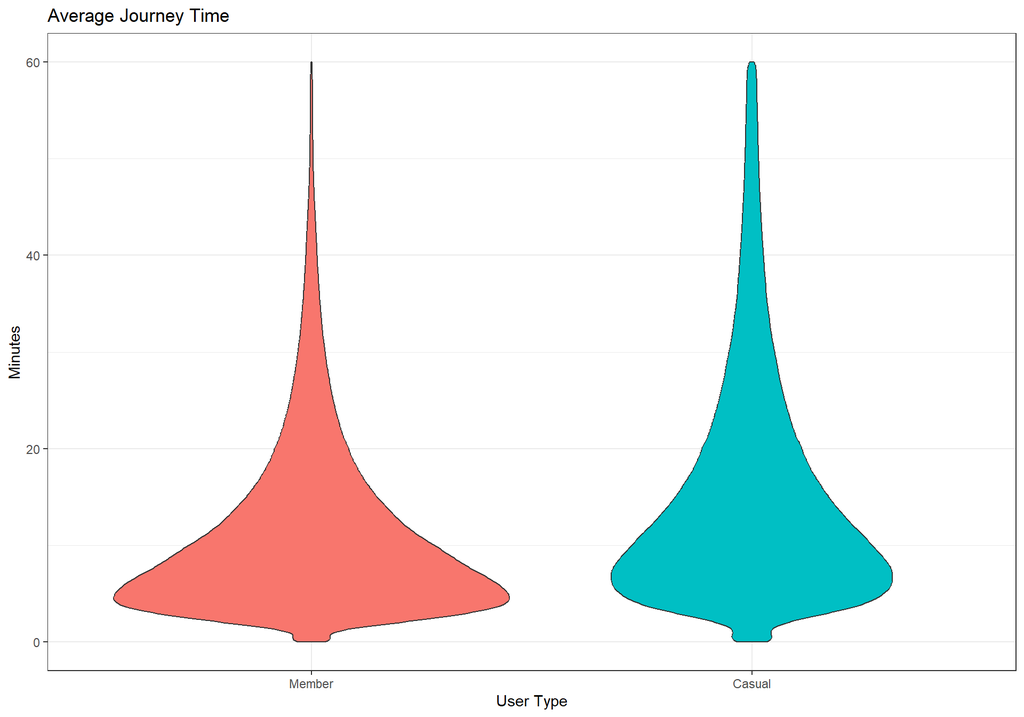

```r
g_mcWRTtl_v <- mcWRTtl %>%
  ggplot(aes(m_c, length, fill = m_c)) +
  geom_violin(show.legend = FALSE) +
  ylim(0, 60) +
  labs(x = "User Type", y = "Minutes", title = "Average Journey Time") +
  scale_x_discrete(labels = c("Member", "Casual")) +
  theme_bw()

g_mcWRTtl_v
```

Casual journey length is on average longer than Member journey length. Could be several reasons for longer average length, likely worth investigating but falls outside of the scope of this current analysis.

## What is the average speed of the two groups?

[figure not shown]

```r
mcWRTas <- tibble("date" = as.Date(trips_wloc$s_at),
                  "time" = hms::as_hms(ymd_hms(trips_wloc$s_at)),
                  "m_c" = trips_wloc$m_c,
                  "speed" = trips_wloc$spd_kph)

g_mcWRTas <- mcWRTas %>%
  ggplot(aes(m_c, speed, fill = m_c)) +
  geom_boxplot(show.legend = FALSE, outlier.shape = NA) +
  labs(x = "User Type", y = "Speed - km/h", title = "Average Journey Speed") +
  scale_x_discrete(labels = c("Member", "Casual")) +
  theme_bw()

g_mcWRTas
```

[figure not shown]

```r
g_mcWRTas_v <- mcWRTas %>%
  ggplot(aes(m_c, speed, fill = m_c)) +
  geom_violin(show.legend = FALSE) +
  labs(x = "User Type", y = "Speed - km/h", title = "Average Journey Speed") +
  scale_x_discrete(labels = c("Member", "Casual")) +
  theme_bw()

g_mcWRTas_v
```

```r
mcWRTas_y <- mcWRTas %>%
  group_by(date, m_c) %>%
  summarise("avg_speed" = mean(speed))
```

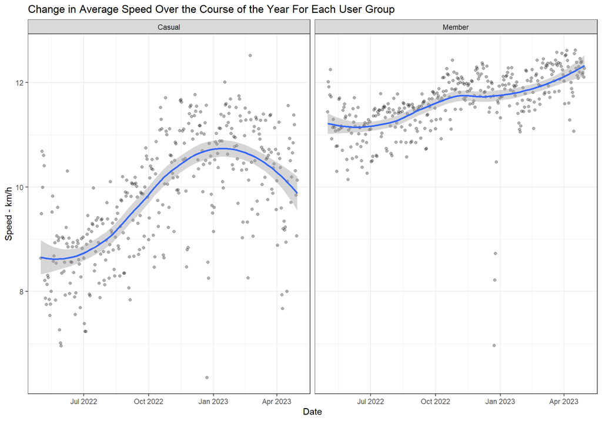

```r
g_mcWRTas_y <- mcWRTas_y %>%
  ggplot(aes(date, avg_speed)) +
  geom_point(alpha = 0.3) +
  geom_smooth() +
  labs(x = "Date", y = "Speed - km/h",
       title = "Change in Average Speed Over the Course of the Year For Each User Group") +
  facet_wrap(~m_c,
             labeller = labeller(m_c = c("member" = "Member",
                                         "casual" = "Casual"))) +
  theme_bw()

g_mcWRTas_y
```

The pace of Members are consistently quicker; while the pace of Casual users is slower during the summer, proceeding to increase significantly over the winter.

## What are the differences in docking stations used by the two groups?

[figure not shown]

Docking Graph 1

Inner City is used more by Casual users; whereas Members use the rural and suburban areas more. Perhaps a cheaper “Inner City” membership limited to use in a specific area/zone.

## How does the popularity of stations compare against the number of docks at the station?

(Are some stations running out of available bikes)

[figure not shown]

Docking Graph 2

Definite discrepancies between usage levels and station size, but more info would be needed to affirm concrete deductions and actionable steps.

## Are there any connections between particular high/low member/casual usage and location?

See Docking Graph 1 above

## The regularity of trips(to/from work etc…)?

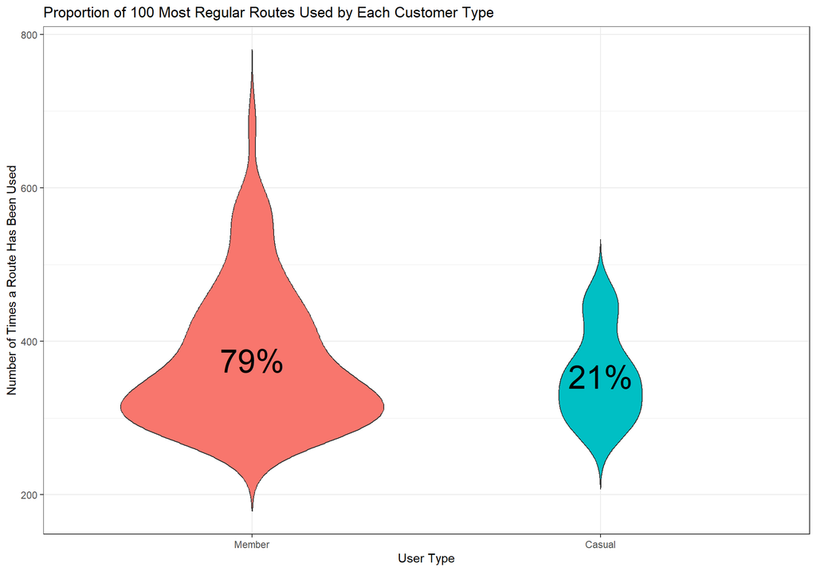

```r
freqtrips <- tibble("s_stn" = trips_wloc$s_stn,
                    "e_stn" = trips_wloc$e_stn,
                    "s_at" = hms::as_hms(ymd_hms(trips_wloc$s_at)),
                    "e_at" = hms::as_hms(ymd_hms(trips_wloc$e_at)),
                    "m_c" = trips_wloc$m_c)

freqtrips$s_at <- hms::round_hms(freqtrips$s_at, digits = -4)
freqtrips$e_at <- hms::round_hms(freqtrips$e_at, digits = -4)

freqtrips$m_c <- factor(freqtrips$m_c, levels = c("member", "casual"))


freqtrips <- freqtrips %>%
  group_by(s_stn, e_stn, s_at, e_at, m_c) %>%
  tally()

freqtrips <- arrange(freqtrips, desc(n))

i = 100

freq_label <- freqtrips %>%
  head(i) %>%
  group_by(m_c) %>%
  dplyr::summarize(freq = n(), n = mean(n))

g_freqtrips_100 <- freqtrips %>%
  head(., i) %>%
  ggplot(aes(x = m_c, y = n, fill = m_c)) +
  geom_violin(scale = "count", trim = F, show.legend = FALSE) +
  scale_x_discrete(labels = c("Member", "Casual")) +
  theme_bw() +
  geom_text(aes(label = paste0(formatC((freq/i) * 100, format = "f",
                                       digits = 0), "%")),
            size = 10, data = freq_label) +
  labs(x = "User Type", y = "Number of Times a Route Has Been Used",
       title = paste("Proportion of", as.character(i),
                     "Most Regular Routes Used by Each Customer Type"))

g_freqtrips_100
```

Not only do Members have a higher proportion of the 100 most used routes, but they also lay claim to the most used routes overall. While members have a significant percentage of the top most traveled routes there is still a sizable number of regular casual routes. Perhaps focused advertising along these regular routes would yield more efficient marketing; or an alternative cheaper membership option that only covered access to journeys around these areas would prove successful.

It should be noted that without access to specific user linked data, there is again no way of knowing if these trips are by one person or 1000 people; which greatly weakens the strength of the finding. However, with such promising early numbers, I’d argue that it warrants it’s own analysis, further to the current one.

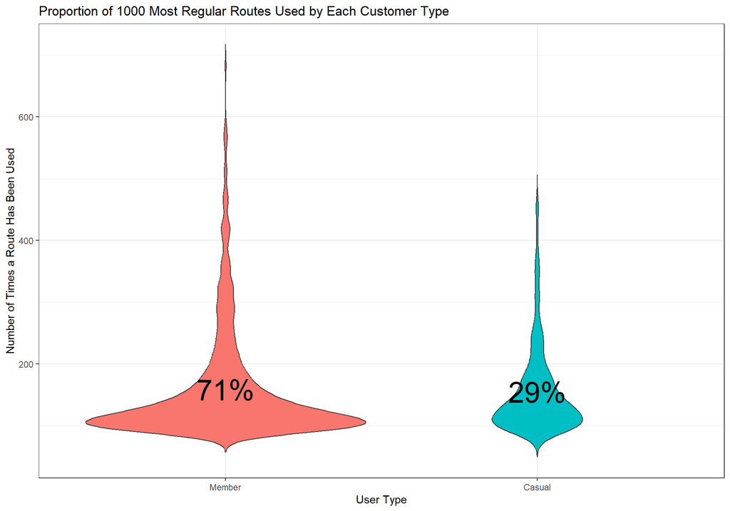

```r
j = 1000

freq_label_j <- freqtrips %>%
  head(j) %>%
  group_by(m_c) %>%
  dplyr::summarize(freq = n(), n = mean(n))

g_freqtrips_1000 <- freqtrips %>%
  head(., j) %>%
  ggplot(aes(x = m_c, y = n, fill = m_c)) +
  geom_violin(scale = "count", trim = F, show.legend = FALSE) +
  scale_x_discrete(labels = c("Member", "Casual")) +
  theme_bw() +
  geom_text(aes(label = paste0(formatC((freq/j) * 100, format = "f",
                                       digits = 0), "%")),
            size = 10, data = freq_label_j) +
  labs(x = "User Type", y = "Number of Times a Route Has Been Used",
       title = paste("Proportion of", as.character(j),
                     "Most Regular Routes Used by Each Customer Type"))

g_freqtrips_1000
```

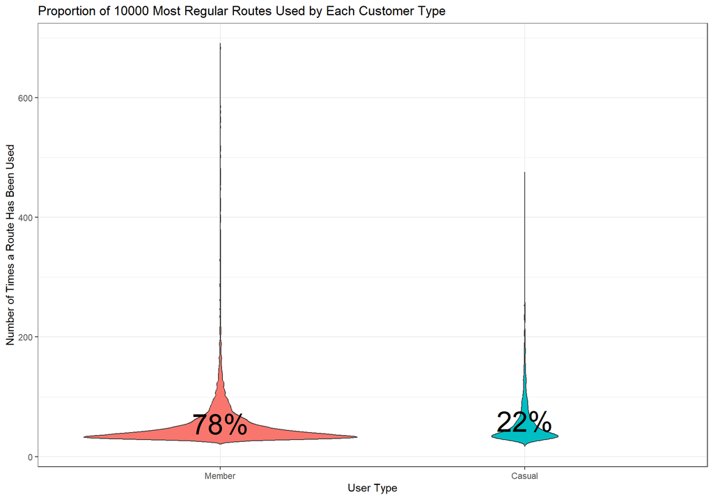

```r
k = 10000

freq_label_k <- freqtrips %>%
  head(k) %>%
  group_by(m_c) %>%
  dplyr::summarize(freq = n(), n = mean(n))

g_freqtrips_10000 <- freqtrips %>%
  head(., k) %>%
  ggplot(aes(x = m_c, y = n, fill = m_c)) +
  geom_violin(scale = "count", trim = F, show.legend = FALSE) +
  scale_x_discrete(labels = c("Member", "Casual")) +
  theme_bw() +
  geom_text(aes(label = paste0(formatC((freq/k) * 100, format = "f",
                                       digits = 0), "%")),
            size = 10, data = freq_label_k) +
  labs(x = "User Type", y = "Number of Times a Route Has Been Used",
       title = paste("Proportion of", as.character(k),
                     "Most Regular Routes Used by Each Customer Type"))

g_freqtrips_10000
```

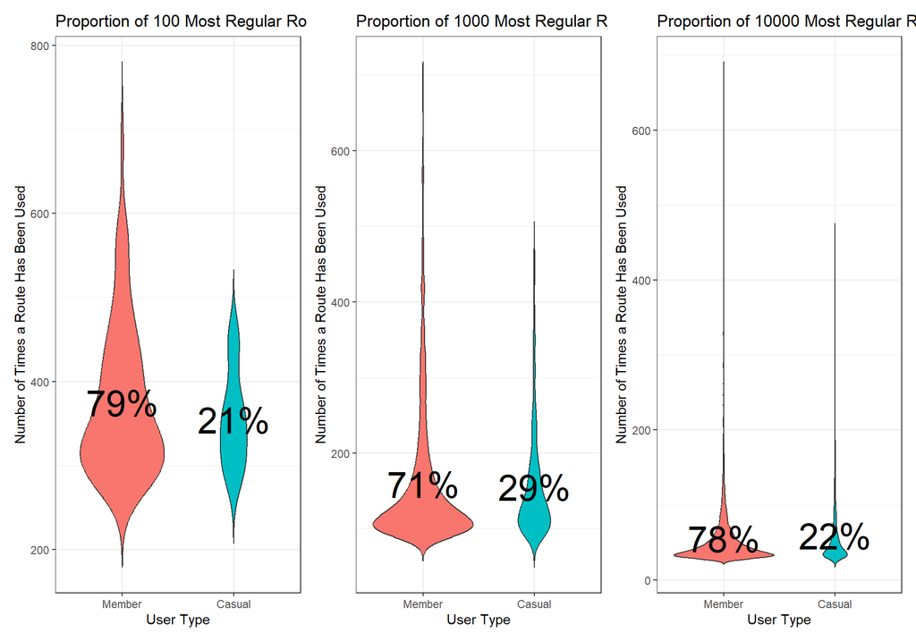

```r
g_freqtrips_100 + g_freqtrips_1000 + g_freqtrips_10000
```

```r
remove(freqtrips, freq_label, i, j, k, freq_label_j, freq_label_k)
```

This trend is repeated right up to the 10000 Most regular trips.

NB. There is some inaccuracy with this method due to the cut off being the 10,000th entry. The 10,001st entry and so on will likely have the same n value (number of times the route has been used) but isn’t included in the plot. As this is a first pass review and there is no obvious bias favouring one user type over the other, this error is acceptable.

Could be worth looking into the location of these high usage routes for each group; whether it matches up to the station usage analysis above, and if it could be used to narrow down a zone for which Casual users more regularly use the service and thus likely more favourable for conversion to Members.

## What are the preferences for electric bikes vs classic bikes between the two groups

```r
mc_WRT_bt <- tibble("id" = trips$ride_id,
                    "bike_type" = trips$rideable_type,
                    "m_c" = trips$m_c)

mc_WRT_bt <- mc_WRT_bt %>%
  group_by(bike_type, m_c) %>%
  summarise("total" = n())
```

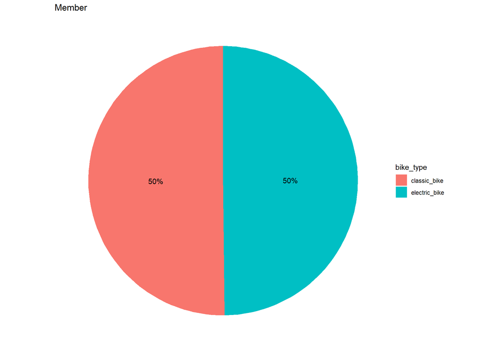

```r
mcWRTbt_m <- mc_WRT_bt %>%
  filter(m_c == "member")

g_mcWRTbt_m <- mcWRTbt_m %>%
  ggplot(aes(x = "", y = total/sum(total), fill = bike_type)) +
  geom_col() +
  coord_polar(theta = "y") +
  labs(title = "Member") +
  geom_text(aes(label = c(paste0(round((total/sum(total))*100, 0), "%"))),
            position = position_stack(vjust = 0.5)) +
  theme_void()

g_mcWRTbt_m
```

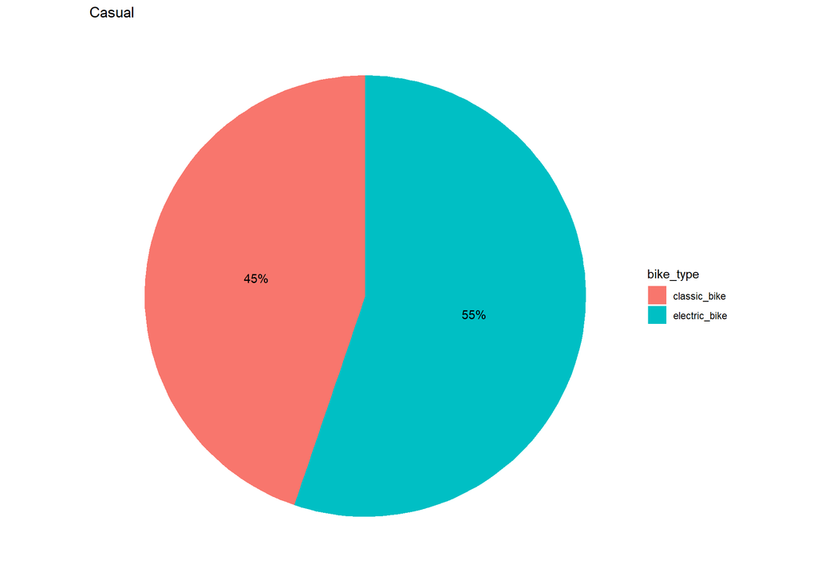

```r
mcWRTbt_c <- mc_WRT_bt %>%
  filter(m_c == "casual")

g_mcWRTbt_c <- mcWRTbt_c %>%
  ggplot(aes(x = "", y = total/sum(total), fill = bike_type)) +
  geom_col() +
  coord_polar(theta = "y") +
  labs(title = "Casual") +
  geom_text(aes(label = c(paste0(round((total/sum(total))*100, 0), "%"))),
            position = position_stack(vjust = 0.5)) +
  theme_void()

g_mcWRTbt_c
```

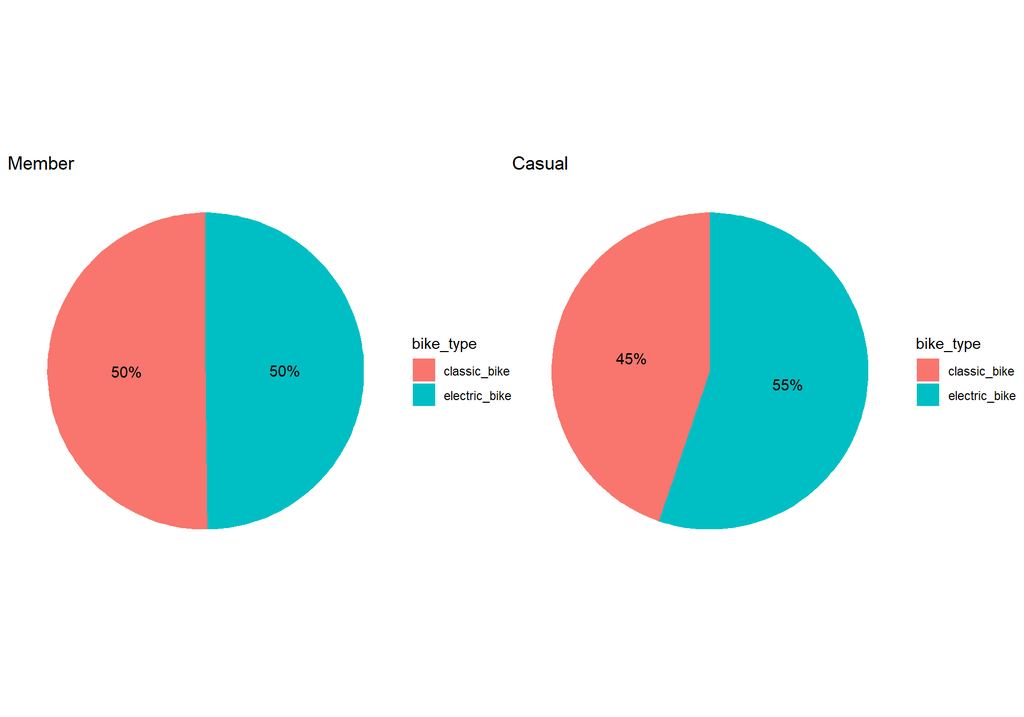

```r
g_mcWRTbt_m + g_mcWRTbt_c
```

```r
remove(mc_WRT_bt, mcWRTbt_c, mcWRTbt_m)
```

Casuals look to prefer electric bikes to classic pedal bikes; and more so than that of member users. However, without information on the availability it shouldn’t be definitively relied upon.

## Looking at bike type preference across the year and across the two user groups

```r
bike_type <- trips %>%
  mutate("date" = as.Date(s_at)) %>%
  group_by(date, rideable_type) %>%
  summarise("total" = n())
```

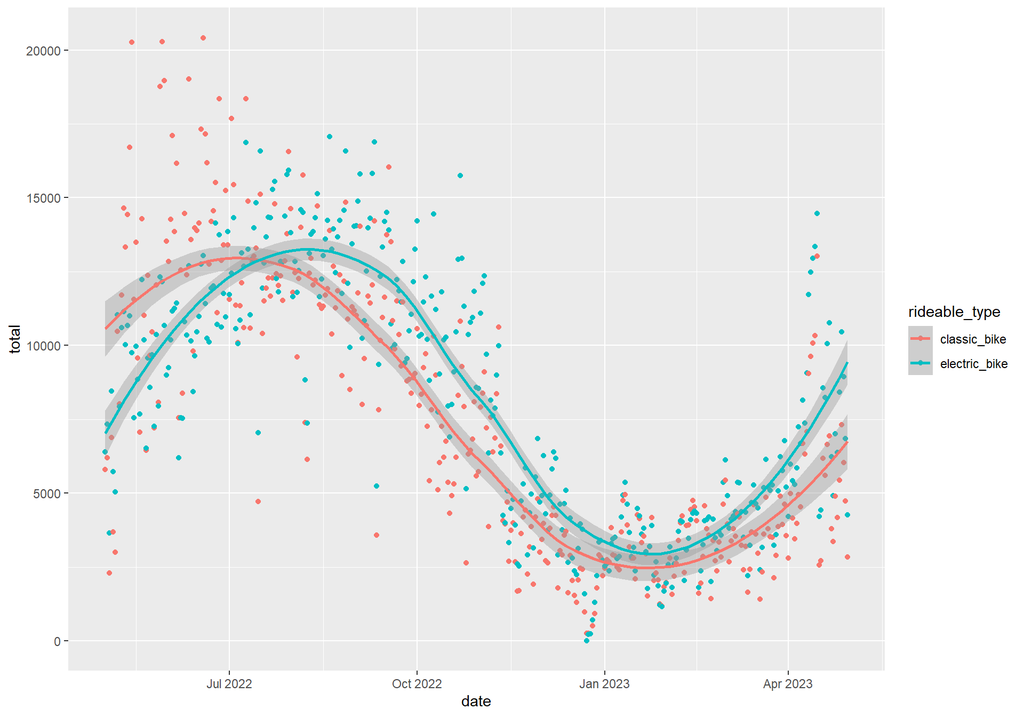

```r
g_bt <- bike_type %>%
  ggplot(aes(date, total, colour = rideable_type)) +
  geom_point() +
  geom_smooth()

g_bt
```

```r
bike_type2 <- trips %>%
  mutate("date" = as.Date(s_at)) %>%
  group_by(date, rideable_type, m_c) %>%
  summarise("total" = n())
```

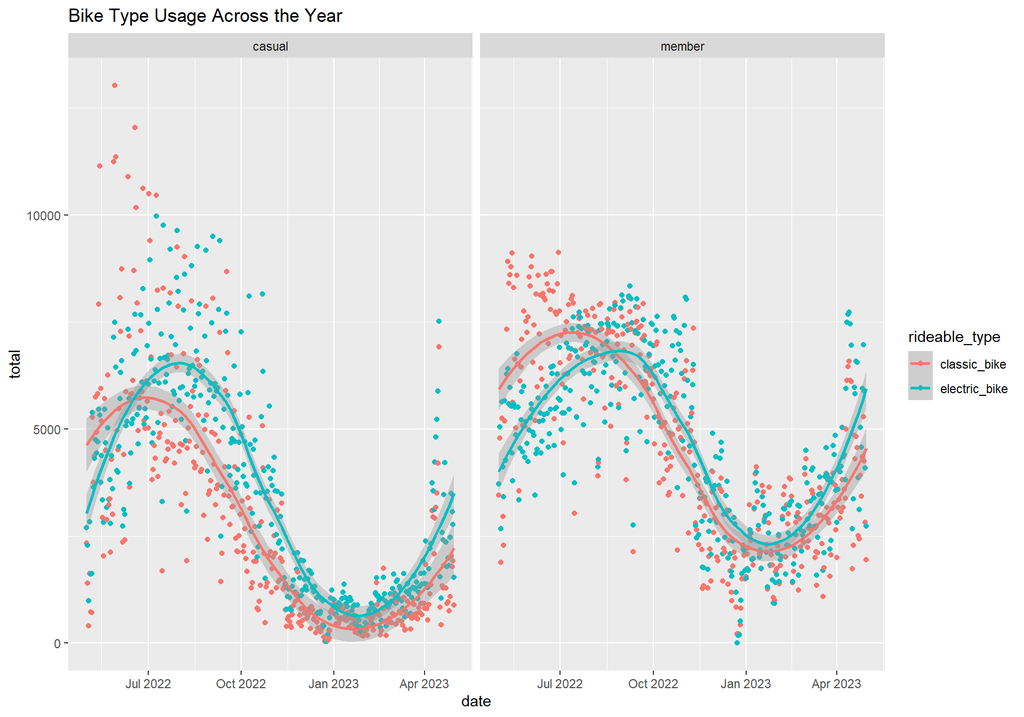

```r
g_bt2 <- bike_type2 %>%
  ggplot(aes(date, total, colour = rideable_type)) +
  geom_point() +
  geom_smooth() +
  labs(title = "Bike Type Usage Across the Year") +
  facet_wrap(~m_c)

g_bt2
```

Again the data reflects the difficulty of definitive conclusions without knowing information on the availability of bikes for users.

## What are the differences in the group size/composition during trips of the two groups?

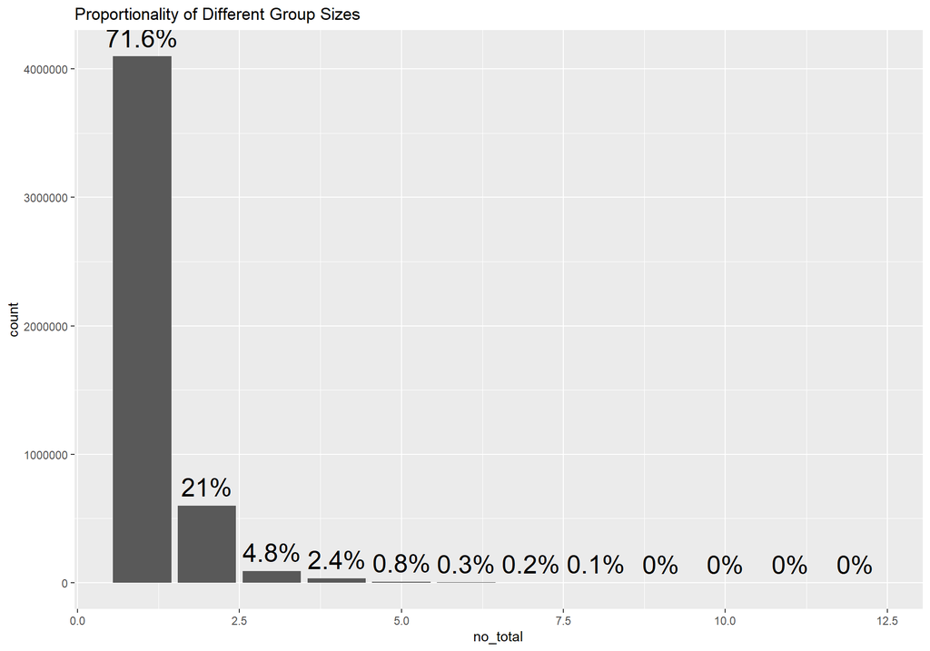

```r
group_analysis <- tibble("route_key" = paste(trips_wloc$s_stn, trips_wloc$e_stn, sep = "_"),
                         "s_at" = as_datetime(trips_wloc$s_at),
                         "e_at" = as_datetime(trips_wloc$e_at),
                         "m_c" = trips_wloc$m_c)

group_analysis <- group_analysis %>%
  arrange(s_at) %>%
  arrange(route_key)

group_analysis$group <- cumsum(c(1, diff.Date(group_analysis$s_at)) >= 120)

group_analysis <- group_analysis %>%
  arrange(e_at) %>%
  arrange(route_key)

group_analysis$group_2 <- cumsum(c(1, diff.Date(group_analysis$e_at)) >= 120)

ga_total <- group_analysis %>%
  group_by(route_key, group, group_2) %>%
  tally(name = "no_total")

ga_casual <- group_analysis %>%
  filter(m_c == "casual") %>%
  group_by(route_key, group, group_2) %>%
  tally(name = "no_casual")

ga_member <- group_analysis %>%
  filter(m_c == "member") %>%
  group_by(route_key, group, group_2) %>%
  tally(name = "no_member")

ga <- full_join(ga_casual, ga_member, by = join_by(route_key, group, group_2))

ga <- left_join(ga, ga_total, by = join_by(route_key, group, group_2))

ga$group_key <- seq(1:nrow(ga))

ga_a <- ga %>%
  group_by(no_total) %>%
  summarise(count = sum(no_total))

ga_a$pct <- ((ga_a$count * ga_a$no_total) / 5723727) * 100

g_gaa <- ga_a %>%
  ggplot(aes(x = no_total, y = count, label = paste0(round(pct, 1), "%") )) +
  geom_col() +
  labs(title = "Proportionality of Different Group Sizes") +
  geom_text(position = position_dodge(width = .9), vjust = -0.5, size = 7)

g_gaa
```

Only groups of 2 and 3 have what I consider to be a significant enough proportion of total trips to warrant a further look

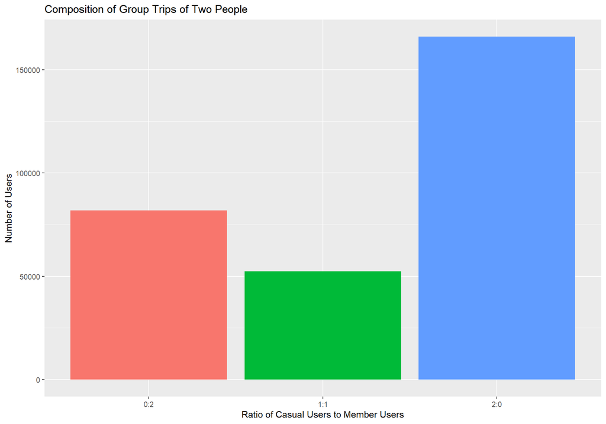

```r
ga_23 <- ga %>%
  filter(between(no_total, 2, 3))

ga_23[is.na(ga_23)] <- 0

ga_23$ratio <- ifelse(ga_23$no_total == 2, "0:2", "0:3")
ga_23$ratio[ga_23$no_total == 2 & ga_23$no_casual == 1] <- "1:1"
ga_23$ratio[ga_23$no_total == 2 & ga_23$no_casual == 2] <- "2:0"
ga_23$ratio[ga_23$no_total == 3 & ga_23$no_casual == 1] <- "1:2"
ga_23$ratio[ga_23$no_total == 3 & ga_23$no_casual == 2] <- "2:1"
ga_23$ratio[ga_23$no_total == 3 & ga_23$no_casual == 3] <- "3:0"

ga_23$ratio <- as.factor(ga_23$ratio)

g_ga2 <- ga_23 %>%
  filter(no_total == 2) %>%
  ggplot(aes(ratio, fill = ratio)) +
  geom_bar(show.legend = F) +
  labs(x = "Ratio of Casual Users to Member Users",
       y = "Number of Users",
       title = "Composition of Group Trips of Two People")

g_ga2
```

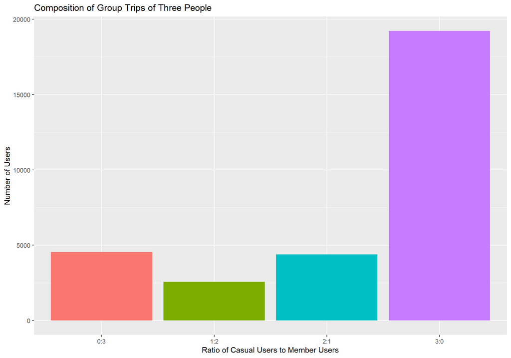

```r
g_ga3 <- ga_23 %>%
  filter(no_total == 3) %>%
  ggplot(aes(ratio, fill = ratio)) +
  geom_bar(show.legend = F) +
  labs(x = "Ratio of Casual Users to Member Users",
       y = "Number of Users",
       title = "Composition of Group Trips of Three People")

g_ga3
```

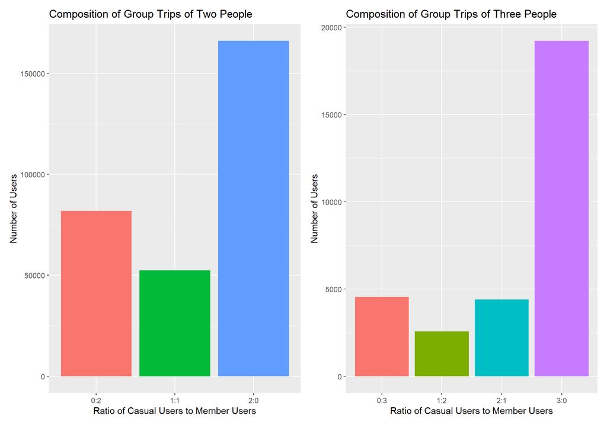

```r
g_ga2 + g_ga3
```

```r
 remove(ga, ga_casual, ga_member, ga_total, group_analysis, ga_23, ga_a)
```

Both group sizes show heavy preference to Casual users, specifically only consisting of casual users. Perhaps an offer on groups of 2 people would address the needs of a large contingent of the Casual user.

## Are there any dips in casual usage that align with rise in member usage?

```r
g_mcWRTtime
```

Would really need a wider data set to measure the year over year changes to remove the influence of seasonal changes. Or alternatively data on new account/membership records to accurately determine any relationship here.

# 2nd Pass

Now take the strongest cases studied and refine them for use to build an actionable plan

## Formulating the strongest and most promising data and conclusions into a report:

Points that hold the most weight: - Casual usage summer increase - Casual usage weekend increase - Casual usage inner city increase - Casual usage group trips

The most impactful of these is the summer and weekend increases

## Graphing Daily Journey Totals against Time

```r
g_mcWRTtime
```

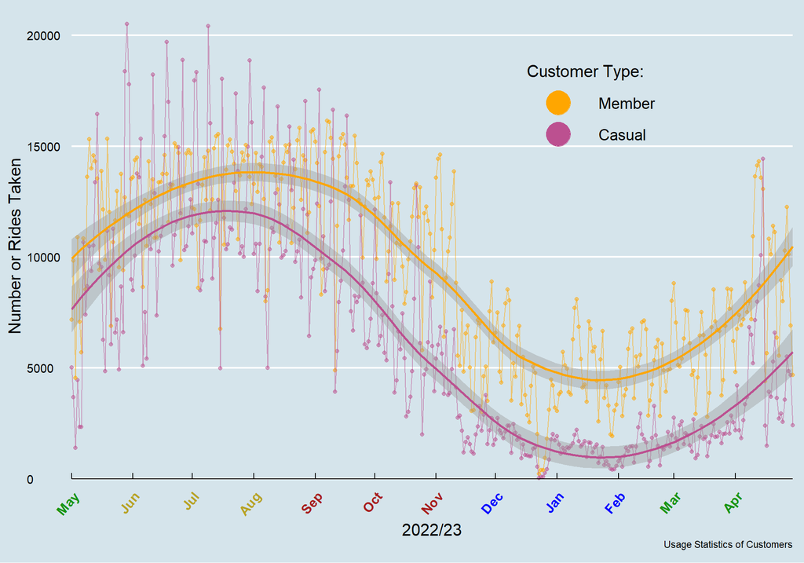

```r
mcWRTtime <- tibble("date" = as.Date(trips$s_at), "m_c" = trips$m_c)
mcWRTtime <- table(mcWRTtime)
mcWRTtime <- as.data.frame(mcWRTtime)
mcWRTtime$date <- as.Date(as.character(mcWRTtime$date), format="%Y-%m-%d")
mcWRTtime$m_c <- factor(mcWRTtime$m_c, levels = c("member", "casual"))

colour_ref <- c('#179412', '#b7a224', '#b7a224', '#b7a224', '#a71d1d', '#a71d1d', '#a71d1d',
                   'blue', 'blue', 'blue', '#179412', '#179412')

g_mcWRTtime <- mcWRTtime %>%
  ggplot(aes(date, Freq, color = m_c, group = m_c)) +
  geom_point(alpha = 0.5) +
  geom_line(alpha = 0.5, show.legend = F) +
  geom_smooth(show.legend = F) +
  labs(x = "2022/23",
       y = "Number or Rides Taken",
       caption = "Usage Statistics of Customers",
       color = "Customer Type:") +
  scale_x_date(breaks = "1 month", date_labels = "%b") +
  scale_colour_manual(values = c("#ffa600", "#bc5090"),
                      labels = c("Member", "Casual")) +
  ylim(c(0, 21000)) +
  coord_cartesian(expand = FALSE, clip = "off") +
  theme_economist() +
  theme(axis.title.x = element_text(vjust = -.5, size = 15),
        axis.title.y = element_text(vjust = 2, size = 15),
        axis.text.x = element_text(angle = 50, vjust = 1, hjust = 1, size = 12,
                                   colour = colour_ref, face = 'bold'),
        axis.ticks.y = element_blank(),
        legend.position = c(.72, .80),
        legend.title = element_text(size = 15),
        legend.text = element_text(size = 14),
        panel.grid.minor = element_blank(),
        legend.key.size = unit(2, 'cm'),
        legend.key.height = unit(1, 'cm')) +
  guides(color = guide_legend(override.aes = list(size = 10, alpha = 1)))
g_mcWRTtime
```

## Graphing Variance in Daily Journey Totals according to Day of The Week

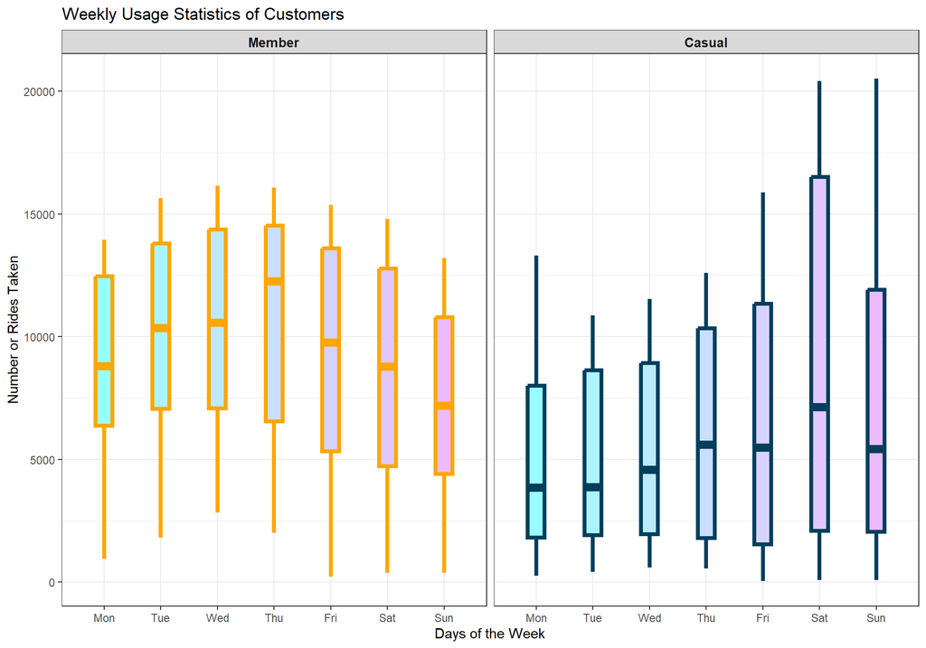

```r
g_mcWRTwd
```

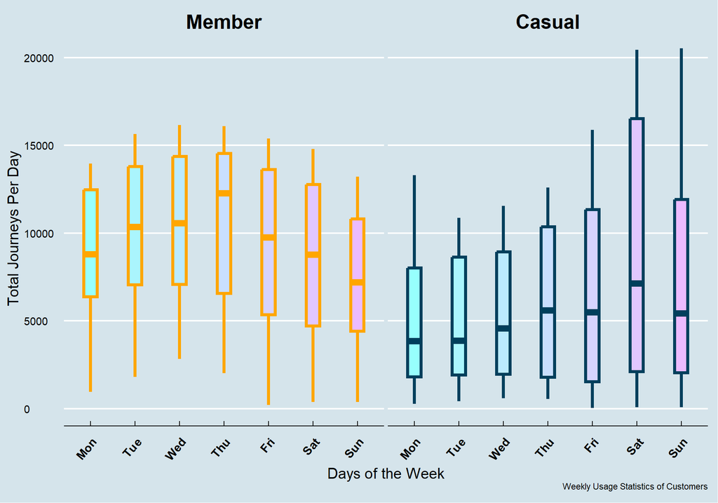

```r
mcWRTwd <- mcWRTtime %>%
  mutate('wd' = wday(mcWRTtime$date, week_start = 1))

g_mcWRTwd <- mcWRTwd %>%
  ggplot(aes(wd, Freq, group = wd, fill = wd, color = m_c)) +
  geom_boxplot(show.legend = F,
               outlier.shape = NA,
               width = .3,
               size = 1.5) +
  labs(x = "Days of the Week",
       y = "Total Journeys Per Day",
       caption = "Weekly Usage Statistics of Customers",
       color = "Customer Type") +
  scale_x_discrete(limits = factor(1:7), labels = c("1" = "Mon", "2" = "Tue",
                                            "3" = "Wed", "4" = "Thu",
                                            "5" = "Fri", "6" = "Sat",
                                            "7" =  "Sun")) +
  scale_colour_manual(values = c("#ffa600", "#003f5c"),
                      labels = c("Member", "Casual")) +
  scale_fill_gradient(low = "#97FFFD", high = "#ECBBFF") +
  facet_wrap(~m_c,
             labeller = labeller(m_c = c("member" = "Member",
                                         "casual" = "Casual"))) +
  theme_economist() +
  theme(strip.text.x = element_text(size = 20, face = "bold"),
        axis.title.x = element_text(vjust = -.5, size = 15),
        axis.title.y = element_text(vjust = 2, size = 15),
        axis.text.x = element_text(angle = 50, vjust = 1, hjust = 1, size = 12,
                                   face = 'bold'))

g_mcWRTwd
```

## Percentage of Casual trips that fall under this “Peak Season” umbrella

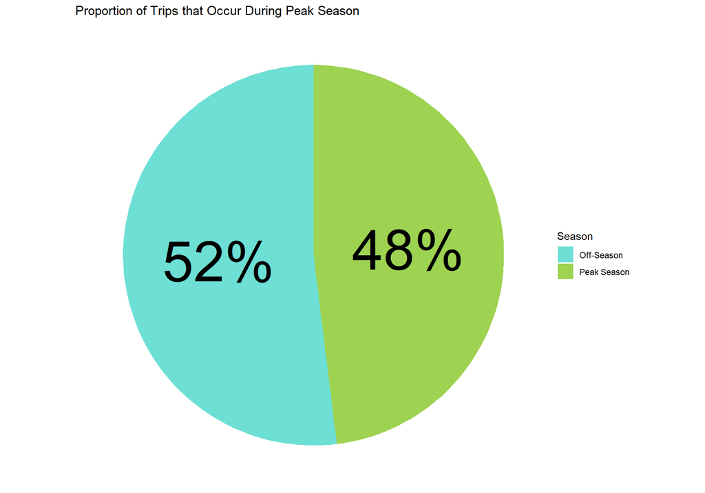

```r
casual_trips <- trips %>%
  filter(m_c == "casual") %>%
  mutate("date" = as.Date(s_at, format = "%Y-%m-%dT%H:%M:%SZ")) %>%
  group_by(date) %>%
  summarise("total" = n()) %>%
  mutate("season" = ifelse(date >= as.Date("01/06/2022", format = "%d/%m/%Y") &
                             date < as.Date("01/09/2022", format = "%d/%m/%Y"),
                           "Peak Season", "Off-Season"),
         "wd" = wday(date, week_start = 1)) %>%
  mutate("we" = ifelse(wd >= 6, T, F))




g_seasonal_usage <- casual_trips %>%
  group_by(season) %>%
  summarise("total" = sum(total)) %>%
  ggplot(aes(x = "", y = total/sum(total), fill = season)) +
  geom_col() +
  coord_polar(theta = "y") +
  scale_fill_manual(values = c("#6DDFD5", "#9ED251")) +
  labs(title = "Proportion of Trips that Occur During Peak Season",
       fill = "Season") +
  geom_text(aes(label = c(paste0(round((total/sum(total))*100, 0), "%"))),
            position = position_stack(vjust = 0.5), size = 20) +
  theme_void()

g_seasonal_usage
```

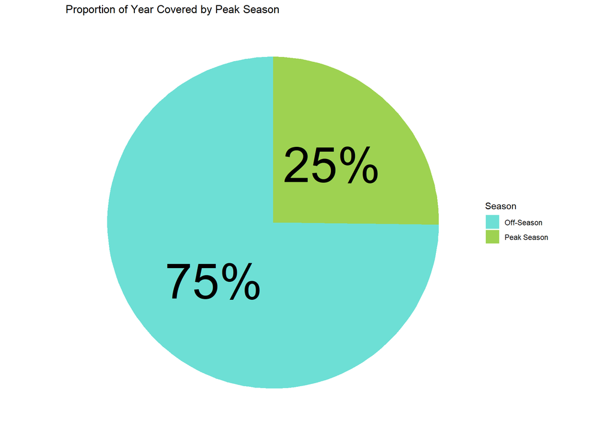

```r
base <- trips %>%
  mutate("date" = as.Date(s_at)) %>%
  group_by(date) %>%
  summarise() %>%
  mutate("season" = ifelse(date >= as.Date("01/06/2022", format = "%d/%m/%Y") &
                             date < as.Date("01/09/2022", format = "%d/%m/%Y"),
                           "Peak Season", "Off-Season"),
         "wd" = wday(date, week_start = 1)) %>%
  mutate("we" = ifelse(wd >= 6, T, F))

g_seasonal_usage_base <- base %>%
  group_by(season) %>%
  summarise("total" = n()) %>%
  ggplot(aes(x = "", y = total/sum(total), fill = season)) +
  geom_col() +
  coord_polar(theta = "y") +
  scale_fill_manual(values = c("#6DDFD5", "#9ED251")) +
  labs(title = "Proportion of Year Covered by Peak Season",
       fill = "Season") +
  geom_text(aes(label = c(paste0(round((total/sum(total))*100, 0), "%"))),
            position = position_stack(vjust = 0.5), size = 20) +
  theme_void()

g_seasonal_usage_base
```

By using this peak season half of all trips by casual users take place during only 25% of the year

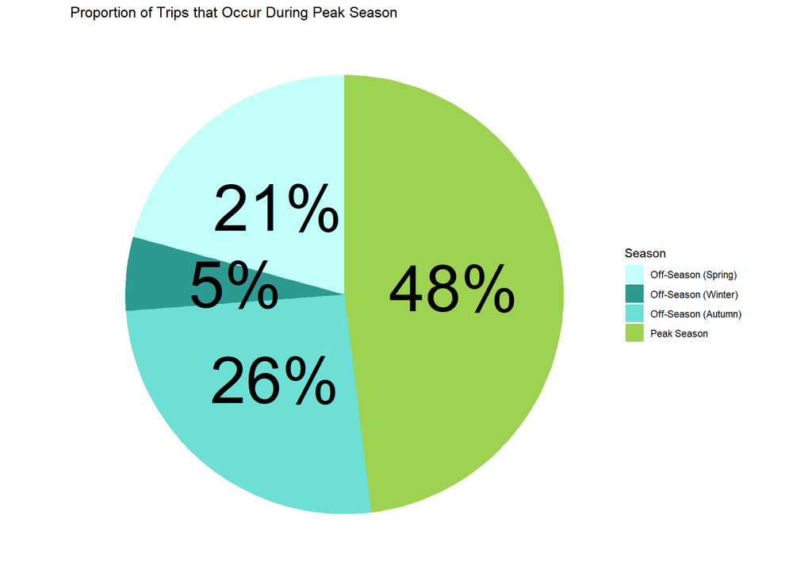

```r
comparison <- casual_trips %>%
  mutate("season" = ifelse(date >= as.Date("01/06/2022", format = "%d/%m/%Y") &
                             date < as.Date("01/09/2022", format = "%d/%m/%Y"),
                           "Peak Season",
                           ifelse(date >= as.Date("01/09/2022", format = "%d/%m/%Y") &
                                    date < as.Date("01/12/2022", format = "%d/%m/%Y"),
                                  "Off-Season (Autumn)",
                                  ifelse(date >= as.Date("01/12/2022", format = "%d/%m/%Y") &
                                           date < as.Date("01/3/2023", format = "%d/%m/%Y"),
                                         "Off-Season (Winter)", "Off-Season (Spring)"))),
         "wd" = wday(date, week_start = 1)) %>%
  mutate("we" = ifelse(wd >= 5, T, F))

comparison$season <- factor(comparison$season,
                                levels = c("Off-Season (Spring)",
                                           "Off-Season (Winter)",
                                           "Off-Season (Autumn)",
                                           "Peak Season"))

g_comparison_s <- comparison %>%
  group_by(season) %>%
  summarise("total" = sum(total)) %>%
  ggplot(aes(x = "", c(3,1,4,2), y = total/sum(total), fill = season)) +
  geom_col() +
  coord_polar(theta = "y") +
  scale_fill_manual(values = c("#C2FFFA", "#2D9A91", "#6DDFD5",  "#9ED251")) +
  labs(title = "Proportion of Trips that Occur During Peak Season",
       fill = "Season") +
  geom_text(aes(label = c(paste0(round((total/sum(total))*100, 0), "%"))),
            position = position_stack(vjust = 0.5), size = 20) +
  theme_void()

g_comparison_s
```

This stark difference is highlighted when compared with other three month periods in the year

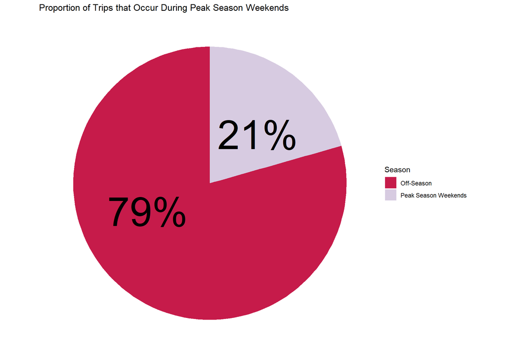

```r
casual_trips_we <- casual_trips %>%
  mutate("season" = ifelse(date >= as.Date("15/05/2022", format = "%d/%m/%Y")
                           & date < as.Date("01/09/2022", format = "%d/%m/%Y")
                           & we == T,
                           "Peak Season Weekends", "Off-Season"))

g_seasonal_weekend_usage <- casual_trips_we %>%
  group_by(season) %>%
  summarise("total" = sum(total)) %>%
  ggplot(aes(x = "", y = total/sum(total), fill = season)) +
  geom_col() +
  coord_polar(theta = "y") +
  scale_fill_manual(values = c("#C61B4A", "#D7CBE1")) +
  labs(title = "Proportion of Trips that Occur During Peak Season Weekends",
       fill = "Season") +
  geom_text(aes(label = c(paste0(round((total/sum(total))*100, 0), "%"))),
            position = position_stack(vjust = 0.6), size = 20) +
  theme_void()

g_seasonal_weekend_usage
```

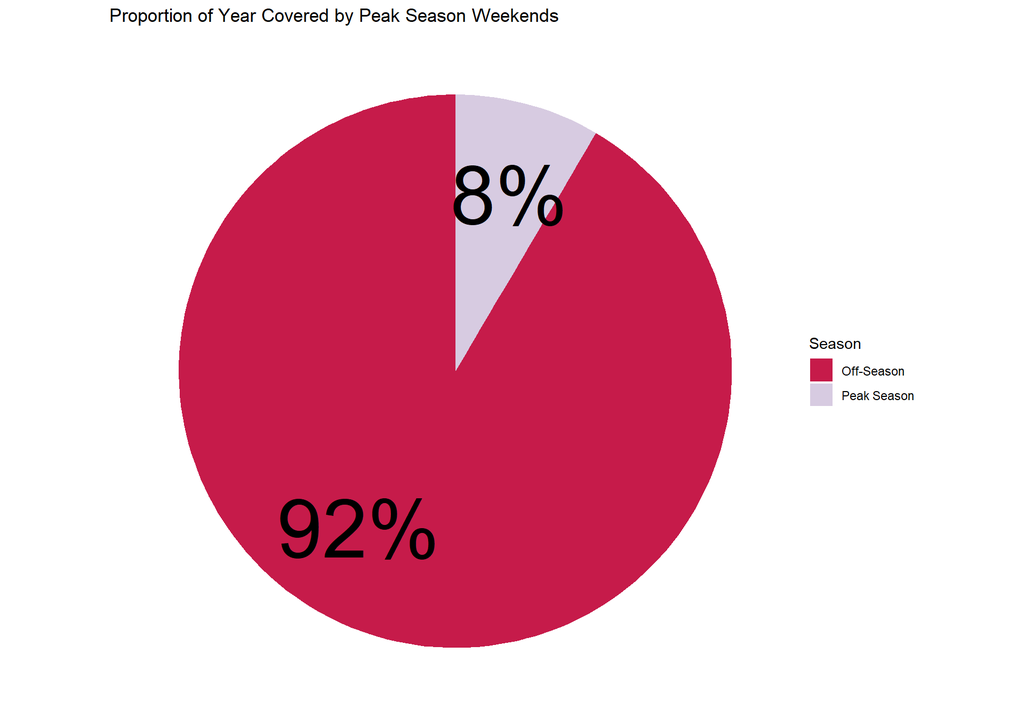

```r
base_we <- base %>%
  mutate("season" = ifelse(date >= as.Date("15/05/2022", format = "%d/%m/%Y")
                           & date < as.Date("01/09/2022", format = "%d/%m/%Y")
                           & we == T,
                           "Peak Season", "Off-Season"))

g_seasonal_weekend_usage_base <- base_we %>%
  group_by(season) %>%
  summarise("total" = n()) %>%
  ggplot(aes(x = "", y = total/sum(total), fill = season)) +
  geom_col() +
  coord_polar(theta = "y") +
  scale_fill_manual(values = c("#C61B4A", "#D7CBE1")) +
  labs(title = "Proportion of Year Covered by Peak Season Weekends",
       fill = "Season") +
  geom_text(aes(x =  1.15, label = c(paste0(round((total/sum(total))*100, 0), "%"))),
            position = position_stack(vjust = 0.55), size = 20) +
  theme_void()

g_seasonal_weekend_usage_base
```

If Divvy want’s to be more conservative in their actions, this area of effect can be narrowed further to just peak season weekends. Which while only affecting 8% of the year, encompasses over a fifth of all trips by casual users.